# Barren Plateaus with PennyLane

où nous additionnons les probabilités marginales de chaque qubit, à

$$C_L = 1 - p{\vert 0\rangle}$$

où nous ne considérons que la probabilité qu'un seul qubit soit dans l'état 0.

Pendant que nous y sommes, faisons en sorte que notre ansatz ressemble un peu plus à celui que nous rencontrerions en essayant de résoudre un problème d'VQE, et ajoutons l'intrication.

```python
def global_cost_simple(rotations):
    for i in range(wires):
        qml.RX(rotations[0][i], wires=i)
        qml.RY(rotations[1][i], wires=i)
    qml.broadcast(qml.CNOT, wires=range(wires), pattern="chain")
    return qml.probs(wires=range(wires))

def local_cost_simple(rotations):
    for i in range(wires):
        qml.RX(rotations[0][i], wires=i)
        qml.RY(rotations[1][i], wires=i)
    qml.broadcast(qml.CNOT, wires=range(wires), pattern="chain")
    return qml.probs(wires=[0])

global_circuit = qml.QNode(global_cost_simple, dev, interface="autograd")

local_circuit = qml.QNode(local_cost_simple, dev, interface="autograd")

def cost_local(rotations):
    return 1 - local_circuit(rotations)[0]
def cost_global(rotations):
    return 1 - global_circuit(rotations)[0]
```

Bien entendu, maintenant que nous avons modifié à la fois notre fonction de coût et notre circuit, nous devons à nouveau analyser le paysage des coûts.

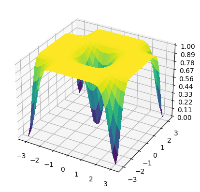

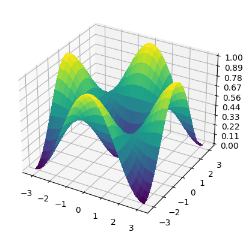

```python
global_surface = generate_surface(cost_global)
plot_surface(global_surface)

local_surface = generate_surface(cost_local)
plot_surface(local_surface)
```

Il semble que nos changements n'aient pas modifié de manière significative le paysage global des coûts. Il ne s'agit probablement pas d'une tendance générale, mais c'est une bonne surprise. Revenons maintenant à l'entraînement des fonctions de coût local et global. Puisque nous disposons d'une visualisation du paysage des coûts totaux, choisissons un point pour exagérer le problème. L'un des pires points du paysage est ( $\pi$ , 0 ) puisqu'il se trouve au milieu du plateau, alors utilisons-le.

```
Cost after step     5:  1.0000000
Cost after step    10:  1.0000000
Cost after step    15:  1.0000000
Cost after step    20:  1.0000000
Cost after step    25:  1.0000000
Cost after step    30:  1.0000000
Cost after step    35:  1.0000000
Cost after step    40:  1.0000000
Cost after step    45:  1.0000000
Cost after step    50:  1.0000000
Cost after step    55:  1.0000000
Cost after step    60:  1.0000000
Cost after step    65:  1.0000000
Cost after step    70:  1.0000000
Cost after step    75:  1.0000000
Cost after step    80:  1.0000000
Cost after step    85:  1.0000000
Cost after step    90:  1.0000000
Cost after step    95:  1.0000000
Cost after step   100:  1.0000000
```

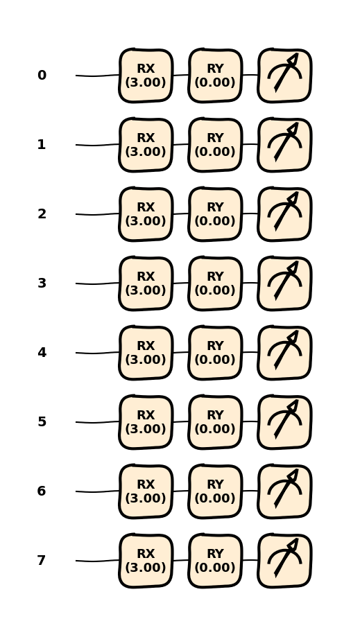

```python
rotations = np.array([[3.] * len(range(wires)), [0.] * len(range(wires))], requires_grad=True)
opt = qml.GradientDescentOptimizer(stepsize=0.2)
steps = 100
params_global = rotations
for i in range(steps):
    # update the circuit parameters
    params_global = opt.step(cost_global, params_global)

    if (i + 1) % 5 == 0:
        print("Cost after step {:5d}: {: .7f}".format(i + 1, cost_global(params_global)))
    if cost_global(params_global) < 0.1:
        break

fig, ax = qml.draw_mpl(global_circuit, decimals=3, style="sketch")(params_global)
plt.show()
```

Après 100 étapes, la fonction de coût est toujours exactement égale à 1. Il est clair que nous nous trouvons dans une zone "non entraînable". Limitons-nous maintenant à la fonction de coût locale et voyons comment elle se comporte.

```
Cost after step     5:  0.9942625
Cost after step    10:  0.9932875
Cost after step    15:  0.9930875
Cost after step    20:  0.9915250
Cost after step    25:  0.9908000
Cost after step    30:  0.9900875
Cost after step    35:  0.9880500
Cost after step    40:  0.9858250
Cost after step    45:  0.9843875
Cost after step    50:  0.9830250
Cost after step    55:  0.9807625
Cost after step    60:  0.9790375
Cost after step    65:  0.9753875
Cost after step    70:  0.9713000
Cost after step    75:  0.9690500
Cost after step    80:  0.9647750
Cost after step    85:  0.9597625
Cost after step    90:  0.9545000
Cost after step    95:  0.9496750
Cost after step   100:  0.9418875
```

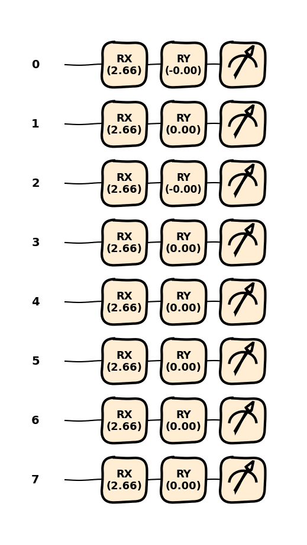

```python
rotations = np.array([[3. for i in range(wires)], [0. for i in range(wires)]], requires_grad=True)
opt = qml.GradientDescentOptimizer(stepsize=0.2)
steps = 100
params_local = rotations
for i in range(steps):
    # update the circuit parameters
    params_local = opt.step(cost_local, params_local)

    if (i + 1) % 5 == 0:
        print("Cost after step {:5d}: {: .7f}".format(i + 1, cost_local(params_local)))
    if cost_local(params_local) < 0.05:
        break

fig, ax = qml.draw_mpl(local_circuit, decimals=3, style="sketch")(params_local)
plt.show()
```

Il est entrainé ! Et beaucoup plus rapidement que dans le cas global. Cependant, nous savons que notre fonction de coût locale est limitée par la fonction globale, mais jusqu'à quel point l'avons-nous entraînée ?

```python
cost_global(params_local)
```

```
1.0
```

Il est intéressant de noter que la fonction de coût global est toujours égale à 1. Si nous avons entraîné la fonction de coût local, pourquoi la fonction de coût global n'a-t-elle pas changé ?

La réponse est que nous avons entraîné le coût global un peu, mais pas suffisamment pour voir un changement avec seulement 10000 shots. Pour que l'effet soit visible, nous devrons augmenter le nombre de tirs dans des proportions déraisonnables. Au lieu de cela, le fait de rendre le backend analytique en définissant les shots sur Aucun, nous donne la représentation exacte.

```python
dev.shots = None
global_circuit = qml.QNode(global_cost_simple, dev, interface="autograd")
print(
    "Current cost: "
    + str(cost_global(params_local))
    + ".\nInitial cost: "
    + str(cost_global([[3.0 for i in range(wires)], [0 for i in range(wires)]]))
    + ".\nDifference: "
    + str(
        cost_global([[3.0 for i in range(wires)], [0 for i in range(wires)]])
        - cost_global(params_local)
    )
)
```

```
Current cost: 0.9999999999972341.
Initial cost: 0.9999999999999843.
Difference: 2.7502444766014378e-12
```

Notre circuit a bien été entraîné, mais pas de manière utile. Si nous essayons d'utiliser ce circuit, il agira de la même manière que si nous ne l'avions jamais entraîné. En outre, si nous essayons maintenant d'entraîner la fonction de coût global, nous nous trouvons encore fermement dans la région du plateau. Afin d'entraîner pleinement le circuit global, nous devrons augmenter progressivement la localité au fur et à mesure de l'entraînement.

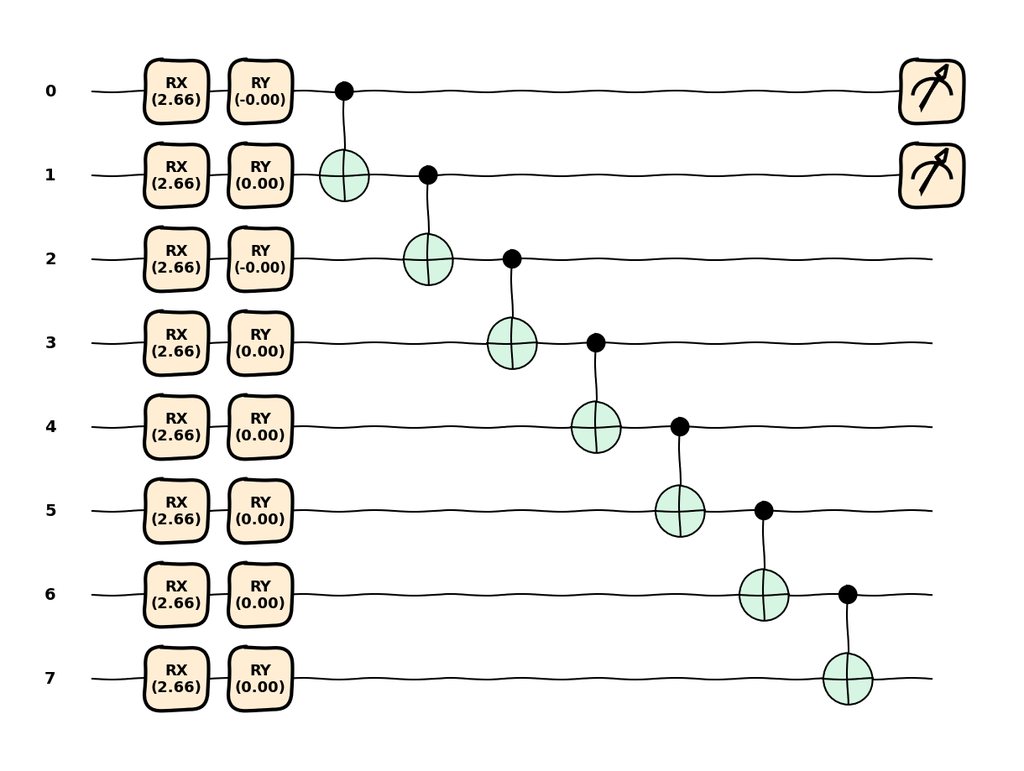

```
0.9965
Cost after step    10:  0.9961000. Locality: 2
Cost after step    20:  0.9965000. Locality: 2
Cost after step    30:  0.9948000. Locality: 2
Cost after step    40:  0.9954000. Locality: 2
Cost after step    50:  0.9949000. Locality: 2
Cost after step    60:  0.9933000. Locality: 2
Cost after step    70:  0.9922000. Locality: 2
Cost after step    80:  0.9914000. Locality: 2
Cost after step    90:  0.9890000. Locality: 2
Cost after step   100:  0.9865000. Locality: 2
Cost after step   110:  0.9808000. Locality: 2
Cost after step   120:  0.9771000. Locality: 2
Cost after step   130:  0.9710000. Locality: 2
Cost after step   140:  0.9628000. Locality: 2
Cost after step   150:  0.9523000. Locality: 2
Cost after step   160:  0.9290000. Locality: 2
Cost after step   170:  0.8830000. Locality: 2
Cost after step   180:  0.8128000. Locality: 2
Cost after step   190:  0.6978000. Locality: 2
Cost after step   200:  0.5092000. Locality: 2
Cost after step   210:  0.3090000. Locality: 2
Cost after step   220:  0.1491000. Locality: 2
---Switching Locality---
Cost after step   230:  0.9196000. Locality: 3
Cost after step   240:  0.8220000. Locality: 3
Cost after step   250:  0.6357000. Locality: 3
Cost after step   260:  0.4116000. Locality: 3
Cost after step   270:  0.2086000. Locality: 3
---Switching Locality---
Cost after step   280:  0.9483000. Locality: 4
Cost after step   290:  0.8742000. Locality: 4
Cost after step   300:  0.7342000. Locality: 4
Cost after step   310:  0.5205000. Locality: 4
Cost after step   320:  0.2916000. Locality: 4
Cost after step   330:  0.1339000. Locality: 4
---Switching Locality---
Cost after step   340:  0.9206000. Locality: 5
Cost after step   350:  0.8173000. Locality: 5
Cost after step   360:  0.6433000. Locality: 5
Cost after step   370:  0.4110000. Locality: 5
Cost after step   380:  0.2001000. Locality: 5
---Switching Locality---
Cost after step   390:  0.9468000. Locality: 6
Cost after step   400:  0.8767000. Locality: 6
Cost after step   410:  0.7369000. Locality: 6
Cost after step   420:  0.5172000. Locality: 6
Cost after step   430:  0.2849000. Locality: 6
Cost after step   440:  0.1356000. Locality: 6
---Switching Locality---
Cost after step   450:  0.9129000. Locality: 7
Cost after step   460:  0.8094000. Locality: 7
Cost after step   470:  0.6421000. Locality: 7
Cost after step   480:  0.4002000. Locality: 7
Cost after step   490:  0.2098000. Locality: 7
---Switching Locality---
Cost after step   500:  0.9404000. Locality: 8
Cost after step   510:  0.8626000. Locality: 8
Cost after step   520:  0.7219000. Locality: 8
Cost after step   530:  0.5103000. Locality: 8
Cost after step   540:  0.2826000. Locality: 8
Cost after step   550:  0.1212000. Locality: 8
```

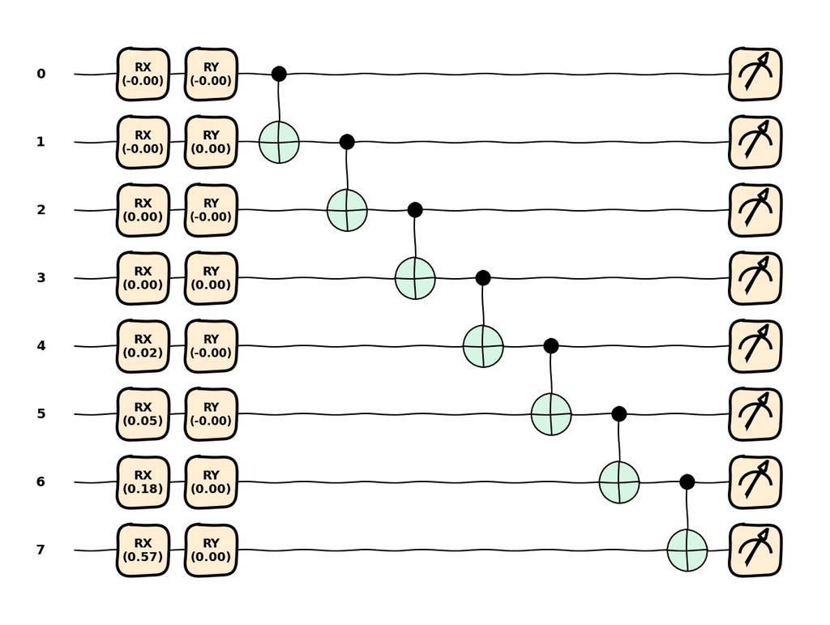

```python
def tunable_cost_simple(rotations):
    for i in range(wires):
        qml.RX(rotations[0][i], wires=i)
        qml.RY(rotations[1][i], wires=i)
    qml.broadcast(qml.CNOT, wires=range(wires), pattern="chain")
    return qml.probs(range(locality))

def cost_tunable(rotations):
    return 1 - tunable_circuit(rotations)[0]

dev.shots = 10000
tunable_circuit = qml.QNode(tunable_cost_simple, dev, interface="autograd")
locality = 2
params_tunable = params_local
fig, ax = qml.draw_mpl(tunable_circuit, decimals=3, style="sketch")(params_tunable)
plt.show()
print(cost_tunable(params_tunable))

locality = 2
opt = qml.GradientDescentOptimizer(stepsize=0.1)
steps = 600

for i in range(steps):
    # update the circuit parameters
    params_tunable = opt.step(cost_tunable, params_tunable)

    runCost = cost_tunable(params_tunable)
    if (i + 1) % 10 == 0:
        print(
            "Cost after step {:5d}: {: .7f}".format(i + 1, runCost)
            + ". Locality: "
            + str(locality)
        )

    if runCost < 0.1 and locality < wires:
        print("---Switching Locality---")
        locality += 1
        continue
    elif runCost < 0.1 and locality >= wires:
        break
fig, ax = qml.draw_mpl(tunable_circuit, decimals=3, style="sketch")(params_tunable)
plt.show()
```

## Une analyse plus approfondie

Le circuit peut maintenant être entraîné, même si nous sommes partis d'un endroit où la fonction globale présente un plateau stérile. Cela signifie que, dans cet exemple, nous pouvons désormais former le circuit à partir de n'importe quel point de départ.

Mais à quelle fréquence ce problème se produit-il ? Si nous voulions entraîner ce circuit à partir d'un point de départ aléatoire, à quelle fréquence serions-nous bloqués sur un plateau ? Pour répondre à cette question, essayons d'entraîner la fonction de coût global à partir de positions de départ aléatoires et comptons le nombre de fois où nous nous retrouvons sur un plateau stérile.

Cela peut prendre jusqu'à 15 minutes.

```python
samples = 10
plateau = 0
trained = 0
opt = qml.GradientDescentOptimizer(stepsize=0.2)
steps = 400
wires = 8

dev = qml.device("lightning.qubit", wires=wires, shots=10000)
global_circuit = qml.QNode(global_cost_simple, dev, interface="autograd")

for runs in range(samples):
    print("--- New run! ---")
    has_been_trained = False

    params_global = np.random.uniform(-np.pi, np.pi, (2, wires), requires_grad=True)

    for i in range(steps):
        # update the circuit parameters
        params_global = opt.step(cost_global, params_global)

        if (i + 1) % 20 == 0:
            print("Cost after step {:5d}: {: .7f}".format(i + 1, cost_global(params_global)))
        if cost_global(params_global) < 0.9:
            has_been_trained = True
            break
    if has_been_trained:
        trained = trained + 1
    else:
        plateau = plateau + 1
    print("Trained: {:5d}".format(trained))
    print("Plateau'd: {:5d}".format(plateau))


samples = 10
plateau = 0
trained = 0
opt = qml.GradientDescentOptimizer(stepsize=0.2)
steps = 400
wires = 8

dev = qml.device("lightning.qubit", wires=wires, shots=10000)
tunable_circuit = qml.QNode(tunable_cost_simple, dev, interface="autograd")

for runs in range(samples):
    locality = 1
    print("--- New run! ---")
    has_been_trained = False

    params_tunable = np.random.uniform(-np.pi, np.pi, (2, wires), requires_grad=True)
    for i in range(steps):
        # update the circuit parameters
        params_tunable = opt.step(cost_tunable, params_tunable)

        runCost = cost_tunable(params_tunable)
        if (i + 1) % 10 == 0:
            print(
                "Cost after step {:5d}: {: .7f}".format(i + 1, runCost)
                + ". Locality: "
                + str(locality)
            )

        if runCost < 0.5 and locality < wires:
            print("---Switching Locality---")
            locality += 1
            continue
        elif runCost < 0.1 and locality >= wires:
            trained = trained + 1
            has_been_trained = True
            break
    if not has_been_trained:
        plateau = plateau + 1
    print("Trained: {:5d}".format(trained))
    print("Plateau'd: {:5d}".format(plateau))
```

```
--- New run! ---
Cost after step    20:  0.9968000
Cost after step    40:  0.9952000
Cost after step    60:  0.9964000
Cost after step    80:  0.9954000
Cost after step   100:  0.9931000
Cost after step   120:  0.9930000
Cost after step   140:  0.9903000
Cost after step   160:  0.9885000
Cost after step   180:  0.9844000
Cost after step   200:  0.9744000
Cost after step   220:  0.9640000
Cost after step   240:  0.9299000
Trained:     1
Plateau'd:     0
--- New run! ---
Cost after step    20:  0.9984000
Cost after step    40:  0.9986000
Cost after step    60:  0.9982000
Cost after step    80:  0.9980000
Cost after step   100:  0.9979000
Cost after step   120:  0.9991000
Cost after step   140:  0.9986000
Cost after step   160:  0.9967000
Cost after step   180:  0.9979000
Cost after step   200:  0.9975000
Cost after step   220:  0.9963000
Cost after step   240:  0.9958000
Cost after step   260:  0.9960000
Cost after step   280:  0.9941000
Cost after step   300:  0.9936000
Cost after step   320:  0.9921000
Cost after step   340:  0.9888000
Cost after step   360:  0.9881000
Cost after step   380:  0.9850000
Cost after step   400:  0.9798000
Trained:     1
Plateau'd:     1
--- New run! ---
Cost after step    20:  0.9975000
```

[output cut: 366 more lines]

```
Cost after step    50:  0.8509000. Locality: 5
Cost after step    60:  0.6903000. Locality: 5
---Switching Locality---
Cost after step    70:  0.7014000. Locality: 6
---Switching Locality---
Cost after step    80:  0.9795000. Locality: 7
Cost after step    90:  0.9460000. Locality: 7
Cost after step   100:  0.8704000. Locality: 7
Cost after step   110:  0.6805000. Locality: 7
---Switching Locality---
Cost after step   120:  0.7359000. Locality: 8
Cost after step   130:  0.4254000. Locality: 8
Cost after step   140:  0.1100000. Locality: 8
Trained:    10
Plateau'd:     0
```

Dans le cas général, entre 70 et 80 % des positions de départ ne sont pas entraînables, ce qui est considérable. Il est probable qu'au fur et à mesure que la complexité de notre ansatz et le nombre de qubits augmentent, ce facteur s'accroîtra.

Nous pouvons comparer cela à notre fonction de coût local, où chaque zone a été entraînée, et la plupart d'entre elles l'ont même été en moins de temps. Bien que ces exemples soient simples, il a été démontré que ce comportement du coût local par rapport au coût global s'étendait à des problèmes plus complexes.